# Introduction to R - Session One

Saturday, January 30, 2016

## Level One: Session One

## Session's goal

- Main goal is to make the necessary preparation for using R
- It will involve getting and setting-up base R and RStudio
- It will also introduce the two programs

## What you will learn

- How to download, and install
  - **Base R**
  - **RStudio**
- Work Interactively with R and RStudio (Using the console)
- Get to know the global environment/working space and history files
- Learn how to code using scripts
- Install and understand what R Packages are

## What is R?

## About R

- A system for statistical computation and graphics (R Documentation)
- A Programming Language
- A dialect of the `S` language and started in 1983
- Partly named after the leading founders `Ross Ihaka` and `Robert Gentleman` first names and partly to bear similarity with `S`
- Began as a program for teaching statistics at a university
- Has since grown with diverse user from all over the world
- A collaborative project with many contributors to the base package as well as extensions (packages)

## Why R?

## Reason to learn R

- It's absolutely free
- Has magnificent graphing capabilites: R's greatest strength.
- It is highly extensible. As a programming language, it allows user defined functions(programs) or packages (add-on)
- R offers a growing number of packages to facilitate reproducible analysis. From these packages, outputs can be documented in various formats like PDF, HTML, microsoft Word, and presentation slides among others
- Available softwares packaged to create interactive statistical application (apps) like shiny
- There is a growing number of users thereby creating a common sharing platform
- A growing number of free and commercial Intergrated Development Environment (IDE's).
- `IDE's` are softwares that ease the coding process, they include RStudio which has a free and a commercial version, and Revolution R which mostly has a commercial version and is best suited for big data.
- To distinguish R from it's IDE's, it is usually refered to as `base R`
- With a good foundation, R is not that hard.
- `My Challenge to you:` put this statement into action and test if it is correct by assessing your knowledge and skills after completing level one (it has four sessions). For example,
  - go to Q&A sites like StackOverflow and find questions on the areas already covered, use the tags and gauge your understanding of the questions and solutions offered.
  - Given a well written R script, do you understand the code?
  - Look at your initial scripts, can you be your own critic? How is your learning curve, have you gotten better with time and practice?

## Base R

## Downloading R

- R is available from The Comprehensive R Archives Network (CRAN)
- CRAN is a collection of web servers that stores identical and up to date version of code and documentation of R
- There are multiple mirrors (copies) of CRAN located across the globe. It is recommended to download from one of the mirrors closest to your area
- Select a platform most suitable to your computer specification (OS, 32/64 bit)
- Lets now download and start it up

## Demo 1: Downloading and Installation of Base R

## Getting to know Base R

## Base R at a glance

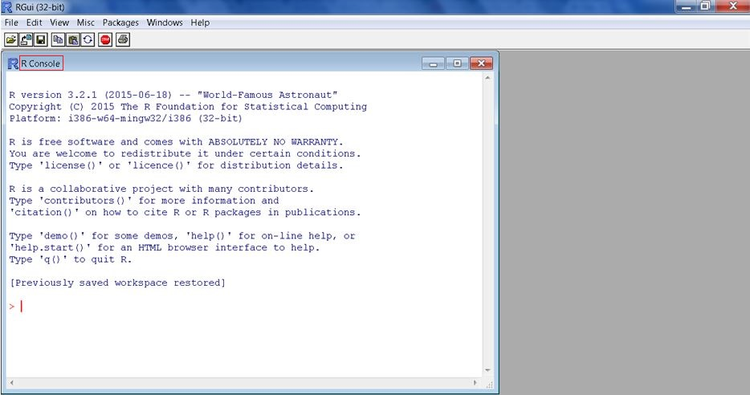

## The toolbar

- **File:** Open/create script, load/save workspace and history, print and exit. Workspace and history files to be discussed later in this session
- **Edit:** Usual edit options plus run options and GUI preference (appearance) options
- **Packages:** selecting mirrors, loading, installing and uninstalling package. Packages are add-ons
- **Windows:** How to arrange the windows
- **Help:** Manuals and help documentation

## The Console

- Also called `Command Line Interface` and acts like a calculator
- Type a code or enter an input on the console and it will be evaluated immediately and their Output produced i.e. interactive
- Being a window just like any other window, you can minimize, maximize, or re-size the window. Try and see
- The console is most suitable for single lines

## Interactive session: The console

```r
# simple arithmetric
1 + 1
```

```
## [1] 2
```

```r
20/2
```

```
## [1] 10
```

```r
# Exponential
exp(1)
```

```
## [1] 2.718282
```

```r
# Some geometry
2 * pi * (90/360)
```

```
## [1] 1.570796
```

```r
# Some trigonometry
cos(90 - 32)
```

```
## [1] 0.1191801
```

```r
atan(28/63)
```

```
## [1] 0.4182243
```

- Note that R is case sensitive, so **Cos** and **cos** are not the same. Useful to know that when you see a "+" instead of ">", know that your syntax is incomplete and R is prompting you to complete it.

## R's Script

- If you were to give someone your code to rerun how would you do it?
- Working on the console gives instant results but not suitable for reproducibility or codes with multiple line, that is where scripts come in
- In essence, scripts are like other text inputing programslike Ms Word and notepad, hence called text editors.
- Text editors are programmed to understand certain programming languages thereby giving guidance in the coding process.
- To create a new script on base R go to `files > New Scripts`

[figure not shown]

## Demo: Scripting in R

## First things first

- What is the first thing you need to do when you start R?
- How can you work on different analysis projects?
- How does R know where to look for documents i need?
- Quick answer to these questions is to **specify your working directory** and **know thy file path**

## Brief introduction to R functions

- To know the current directory or change it, you must use a function
- So what is a function and how do you use them?
- A function in the simplest terms, is a command that performs a specified task
- All functions have a name preceeded by an opening and closing bracket
- Within the brackets are what are called `arguments`. They give further details of how R should implement the command or what data it should use.
- To use a function we refer to it as `calling a function` or `making a function call`
- R has numerous function that come with base R but there many more that come with add-on called `packages`.
- You can also write your own functions with the help of base R functions
- Okay, with that small introduction, let's go back to knowing and setting working directories
- Both `getwd()` and `setwd()` functions require you to know the path to the folder.
- The easiest way of setting the working directory (without specifiying the path), is to use the toolbars:
  - On Base R: file > change dir
  - On RStudio: Session > Set Working Directory > and either:
    - To source file locator: path of an opened R Script
    - To File Pane locator: R Studio's path on your PC
    - Choose Directory: Select a folder from an opened dialog box
- Practice session:
  - Create a folder on your computer called `Data_Mgt_Analysis_and_Graphics_R`
  - Set your working directory to that folder.
- On the command line or console, you can create the folder on the home path as:

```r
dir.create("~/Data_Mgt_Analysis_and_Graphics_R")
```

- To set the working directory to that folder

```r
setwd("~/Data_Mgt_Analysis_and_Graphics_R")
```

- What is a path, a home path and what is that tilde?

## Paths

- A path is a name that specifies a unique location in a computer or website
- So a file path specifies a unique location of a file
- For example *C:/Users/Hellen Gakuruh/Documents/Data Mania/Intro.R*
- Meaning the file is located in a directory called Data Mania, which is in the documents folder, which is in a users folder named Hellen Gakuruh, all of it in the c drive.
- The different folders are separated with what are known as delimeters like the `/` but it could also be `\` or a `.` depending with the operating system
- A path can either be absolute or relative. An absolute path begin from what is called a `root node` like `C:` for windows.A relative path is a shortened path name like `Data Mania/exercises.R`.
- In R, relative paths are used as long as the path for the working directory has been specified
- This path need not start at the root node but to where R was installed which by default is the home path denoted by a tilde (~)
- A home path is a location in the computer inside the root element and specified during installation of the operating system. Most often the `Documents` folder i windows.

## What is the working space or the global environment?

## Working Space/Global Environment

- It is a temporary storage area in the computer memory where R stores data and other objects used in an R session.
- The objects on the working space are only avaliable during the R session but can be saved as ".Rdata" file.
- Saved workspaces are usually reloaded in the next session or can be loaded using:
  - the `load()` function on the console
  - toolbar:
    - On R: file > Load Workspace
    - On RStudio > Session > Load Workspace

## RStudio

## What is RStudio?

- It is one of R's `Integrated Development Environment(IDE)'s`. Some of it's key advantages over base R are:
  - Well thought out and organized layout(panes), making it easy to see all the core windows at the same time.
  - It has a syntax-highlighting editor that supports direct code execution,
  - Workspace management.
  - Makes data importation easier
  - Incorporation of R markdown files makes documentation and reproducible analyis easier.
- It is available for open source and commercial editions and runs on the desktop (Windows, Mac, and Linux) or in a browser connected to RStudio Server or RStudio Server Pro (Debian/Ubuntu, RedHat/CentOS, and SUSE Linux) RStudio.

## Downloading RStudio

- Download from RStudio
- Select platform specific version
- Click the executable file to begin the installation process

## Demo: Downloading and Installing RStudio

## RStudio at a glance

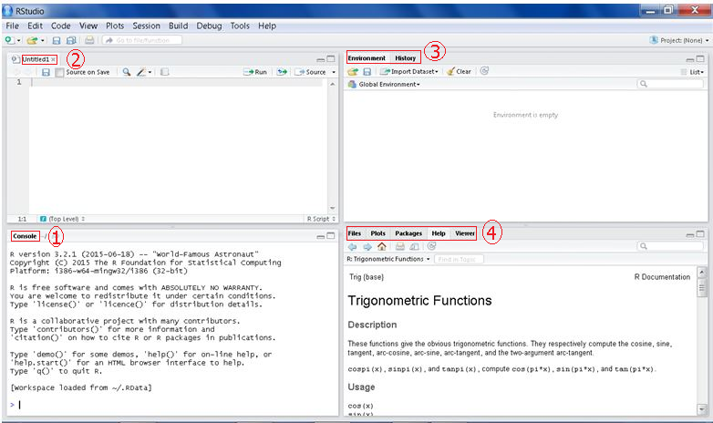

## One: The Console Pane

- This is similar to base R's console
- An interactive platform that you can input commands and generates outputs

## Two: The Script editor and Data Viewer Pane

- The script editor is a better version of the one in base R. One of the core reasons most analysts prefer using IDE's
- The pane can have multiple scripts opened as well as have a a data viewer similar to other analytical programs.

## Four: The Files, Plots, Packages, Help and the Viewer Pane

- The file window which shows the files and directories in the current working directory
- A window to display plots generated
- A window to show the currently installed packages or add-on's
- The help window that displays R documentations and lastly
- The Viewer window used to view local web content

## R Packages

## What are packages

- R packages are extensions that are added to base R
- They are basically specialized functions that are packaged together
- For example, a package could contain functions to develop dynamic graphs (e.g. shiny)
- There are a number of packages that come with base R upon installation
- But many of the packages need to be downloaded from CRAN
- The packages, just like base R and RStudio are free

## Downloading/Installing a package

- There are a number of ways of download a package in R, these are:
  - On Base R: Packages > Install Package(s)
  - On RStudio: Tools > Install Packages
  - On command line type: `install.packages("Name of the package")`
- Note, you have to be online
- Once installed (added to your list of R's packages), the packages are now in the PC but are not available for use. It has to be loaded

## Demo: Downloding and Installing an R package from CRAN